# Report-DataMing

Nhóm 2

2022-06-05

# FinalProject_Telecommunication

# Tên Thành Viên Trong Nhóm

| Name | Student_ID | Task |
| --- | --- | --- |
| Trần Văn Duy | 19133016 | Model Random Forest |
| Nguyễn Duy Phước | 19133003 | Model Logistic Regression |
| Trần Công Trường | 19133062 | Model KNN |
| Cao Anh Văn | 19133067 | Model Decsion Tree |

# 1. Giới thiệu chung

## 1.1. Giới thiệu về bài toán giải quyết

- Bài toán nhóm muốn giải quyết là dự đoán khách hàng có thuộc vào nhóm khách hàng sẽ rời đi hay không để đưa ra phương án giữ khách hàng.
- Theo nghiên cứu đã chỉ ra rằng việc thu hút 1 khách hàng mới tốn nhiều chi phí hơn việc giữ khách hàng hiện tại. Trên thực tế, việc tăng tỷ lệ giữ chân khách hàng chỉ 5% cũng có thể tạo ra lợi nhuận tăng ít nhất 25%.
- Việc dự đoán được khách hàng nào có khả năng rời đi thì sẽ giúp cho người quản lý đưa ra giải pháp kịp thời để không mất đi một khách hàng tiềm năng. (Tham khảo ở https://crmviet.vn/customer-churn-la-gi/)
- Input: Các thông tin cá nhân và thông tin về việc sử dụng dịch vụ của khách hàng: Giới tính, Tình trạng hôn nhân, thời hạn, có sử dụng dịch vụ điện thoại hay không, , , , dịch vụ mạng, hỗ trợ kỹ thuật, video trực tiếp, ,
- Output: chúng em sử dụng thuật toán Decision Tree để dự đoán khách hàng có khả năng rời đi trong tương lai hay không?
- Các nghiên cứu liên quan: Dự đoán hành vi của khách hàng có rời đi hay không, từ đó đưa ra cách giải quyết để giữ chân khách hàng tiềm năng.(Tham khảo ở https://www.profitwell.com/customer-churn/causes)

## 1.2. Giới thiệu về tập dữ liệu

### 1.2.1 Tập dữ liệu

**Tổng quan dataset:**

```
##   customerID           gender          SeniorCitizen      Partner
##  Length:7043        Length:7043        Min.   :0.0000   Length:7043
##  Class :character   Class :character   1st Qu.:0.0000   Class :character
##  Mode  :character   Mode  :character   Median :0.0000   Mode  :character
##                                        Mean   :0.1621
##                                        3rd Qu.:0.0000
##                                        Max.   :1.0000
##
##   Dependents            tenure      PhoneService       MultipleLines
##  Length:7043        Min.   : 0.00   Length:7043        Length:7043
##  Class :character   1st Qu.: 9.00   Class :character   Class :character
##  Mode  :character   Median :29.00   Mode  :character   Mode  :character
##                     Mean   :32.37
##                     3rd Qu.:55.00
##                     Max.   :72.00
##
##  InternetService    OnlineSecurity     OnlineBackup       DeviceProtection
##  Length:7043        Length:7043        Length:7043        Length:7043
##  Class :character   Class :character   Class :character   Class :character
##  Mode  :character   Mode  :character   Mode  :character   Mode  :character
##
##
##
##
##  TechSupport        StreamingTV        StreamingMovies      Contract
##  Length:7043        Length:7043        Length:7043        Length:7043
##  Class :character   Class :character   Class :character   Class :character
##  Mode  :character   Mode  :character   Mode  :character   Mode  :character
##
##
##
##
##  PaperlessBilling   PaymentMethod      MonthlyCharges    TotalCharges
##  Length:7043        Length:7043        Min.   : 18.25   Min.   :  18.8
##  Class :character   Class :character   1st Qu.: 35.50   1st Qu.: 401.4
##  Mode  :character   Mode  :character   Median : 70.35   Median :1397.5
##                                        Mean   : 64.76   Mean   :2283.3
##                                        3rd Qu.: 89.85   3rd Qu.:3794.7
##                                        Max.   :118.75   Max.   :8684.8
##                                                         NA's   :11
##     Churn
##  Length:7043
##  Class :character
##  Mode  :character
##
##
##
##
```

**6 Dòng Đầu :**`

```
##   customerID gender SeniorCitizen Partner Dependents tenure PhoneService
## 1 7590-VHVEG Female             0     Yes         No      1           No
## 2 5575-GNVDE   Male             0      No         No     34          Yes
## 3 3668-QPYBK   Male             0      No         No      2          Yes
## 4 7795-CFOCW   Male             0      No         No     45           No
## 5 9237-HQITU Female             0      No         No      2          Yes
## 6 9305-CDSKC Female             0      No         No      8          Yes
##      MultipleLines InternetService OnlineSecurity OnlineBackup DeviceProtection
## 1 No phone service             DSL             No          Yes               No
## 2               No             DSL            Yes           No              Yes
## 3               No             DSL            Yes          Yes               No
## 4 No phone service             DSL            Yes           No              Yes
## 5               No     Fiber optic             No           No               No
## 6              Yes     Fiber optic             No           No              Yes
##   TechSupport StreamingTV StreamingMovies       Contract PaperlessBilling
## 1          No          No              No Month-to-month              Yes
## 2          No          No              No       One year               No
## 3          No          No              No Month-to-month              Yes
## 4         Yes          No              No       One year               No
## 5          No          No              No Month-to-month              Yes
## 6          No         Yes             Yes Month-to-month              Yes
##               PaymentMethod MonthlyCharges TotalCharges Churn
## 1          Electronic check          29.85        29.85    No
## 2              Mailed check          56.95      1889.50    No
## 3              Mailed check          53.85       108.15   Yes
## 4 Bank transfer (automatic)          42.30      1840.75    No
## 5          Electronic check          70.70       151.65   Yes
## 6          Electronic check          99.65       820.50   Yes
```

**Số dòng :**

```
## [1] 7043
```

**Số cột :**

```
## [1] 21
```

### 1.2.2 Giải thích thuộc tính

- **CustomerID**: id của mỗi khách hàng.
- **Gender**: giới tính ( male, female).
- **SeniorCitizen**: người cao tuổi (0,1).
- **Partner**: Có cộng sự hay không ( yes, no).
- **Dependents**: Có người phụ thuộc hay không ( yes, no).
- **tenure**: số tháng ở lại với công ty.
- **PhoneService**: có sử dụng dịch vụ điện thoại hay không ( yes, no).
- **MultipleLines**: có nhiều đường dây hay không ( yes, no, no phone).
- **InternetService**: nhà cung cấp dịch vụ điện thoại (DSL, có, không).
- **Online Security**: Cho biết liệu khách hàng có đăng ký dịch vụ bảo mật trực tuyến bổ sung do công ty cung cấp hay không (yes, no).
- **OnlineBackup**: dịch vụ sao lưu online ( yes, no, no internet ).
- **DeviceProtection**: dịch vụ bảo vệ thiết bị ( yes, no , no internet).
- **TechSupport**: hỗ trợ kĩ thuật ( yes, no , no internet).
- **StreamingTV**: truyền hình trực tuyến ( yes, no, no internet).
- **Contract**: Cho biết loại hợp đồng hiện tại của khách hàng : Month-to-Month, One Year, Two Year.
- **StreamingMovies**: xem phim trực tuyến ( yes, no , no internet).
- **PaperlessBilling**: thanh toán trực tuyến ( yes, no) .
- **PaymentMethod**: phương thức thanh toán.
- **Monthly Charges**: thanh toán hằng tháng.
- **TotalCharges**: tổng thanh toán.
- **Churn**: quyết định rời đi hay tiếp tục sử dụng dịch vụ ( yes, no).

# 2. Giải quyết bài toán

## 2.1 Thuật toán Decsion Tree

### 2.1.1 Tiền xử lí dữ liệu

> **Kiểm tra tập dữ liệu có giá trị NA hay không ?**

```
##         ColumnTitle NAs
## 1        customerID   0
## 2            gender   0
## 3     SeniorCitizen   0
## 4           Partner   0
## 5        Dependents   0
## 6            tenure   0
## 7      PhoneService   0
## 8     MultipleLines   0
## 9   InternetService   0
## 10   OnlineSecurity   0
## 11     OnlineBackup   0
## 12 DeviceProtection   0
## 13      TechSupport   0
## 14      StreamingTV   0
## 15  StreamingMovies   0
## 16         Contract   0
## 17 PaperlessBilling   0
## 18    PaymentMethod   0
## 19   MonthlyCharges   0
## 20     TotalCharges  11
## 21            Churn   0
```

=> Có một số dòng có cột TotalCharges bị missing value.

> Xóa các dòng có TotalCharges bị NA.

> Cột SeniorCitizen có giá trị 0 và 1 ta sẽ biến đổi về kiểu logical

```
## 'data.frame':    7032 obs. of  21 variables:
##  $ customerID      : chr  "7590-VHVEG" "5575-GNVDE" "3668-QPYBK" "7795-CFOCW" ...
##  $ gender          : chr  "Female" "Male" "Male" "Male" ...
##  $ SeniorCitizen   : logi  FALSE FALSE FALSE FALSE FALSE FALSE ...
##  $ Partner         : chr  "Yes" "No" "No" "No" ...
##  $ Dependents      : chr  "No" "No" "No" "No" ...
##  $ tenure          : int  1 34 2 45 2 8 22 10 28 62 ...
##  $ PhoneService    : chr  "No" "Yes" "Yes" "No" ...
##  $ MultipleLines   : chr  "No phone service" "No" "No" "No phone service" ...
##  $ InternetService : chr  "DSL" "DSL" "DSL" "DSL" ...
##  $ OnlineSecurity  : chr  "No" "Yes" "Yes" "Yes" ...
##  $ OnlineBackup    : chr  "Yes" "No" "Yes" "No" ...
##  $ DeviceProtection: chr  "No" "Yes" "No" "Yes" ...
##  $ TechSupport     : chr  "No" "No" "No" "Yes" ...
##  $ StreamingTV     : chr  "No" "No" "No" "No" ...
##  $ StreamingMovies : chr  "No" "No" "No" "No" ...
##  $ Contract        : chr  "Month-to-month" "One year" "Month-to-month" "One year" ...
##  $ PaperlessBilling: chr  "Yes" "No" "Yes" "No" ...
##  $ PaymentMethod   : chr  "Electronic check" "Mailed check" "Mailed check" "Bank transfer (automatic)" ...
##  $ MonthlyCharges  : num  29.9 57 53.9 42.3 70.7 ...
##  $ TotalCharges    : num  29.9 1889.5 108.2 1840.8 151.7 ...
##  $ Churn           : chr  "No" "No" "Yes" "No" ...
```

> Kịch bản tốt nhất là dự đoán được kết quả tốt nhất với ít biến income nhất. Nên ta sẽ tìm hiểu sự tương quan giữa các biến để loại bỏ một số biến có tương quan cao. Các biến có tương quan cao là dư thừa và không cung cấp bất kỳ thông tin nào. Đôi khi làm cho thuật toán bị lỗi hoặc đem lại kết quả không tốt.

> Đối với 3 biến liên tục

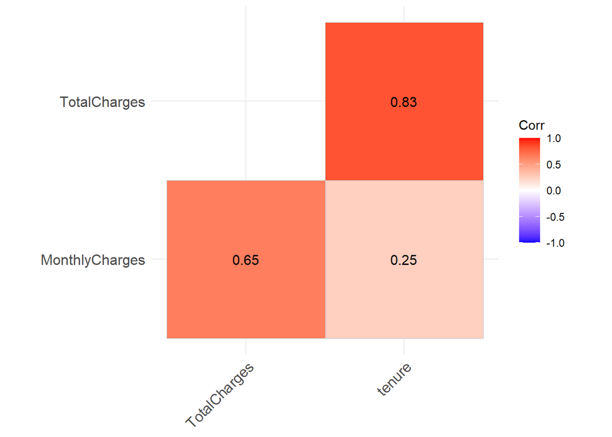

> Từ kết quả ta thấy biến tenure và TotalCharges có tương quan khá cao nên sẽ loại bỏ biến TotalCharges ra khỏi tập dữ liệu dùng để dự đoán.

## 2.1.2 Model

[output not shown]

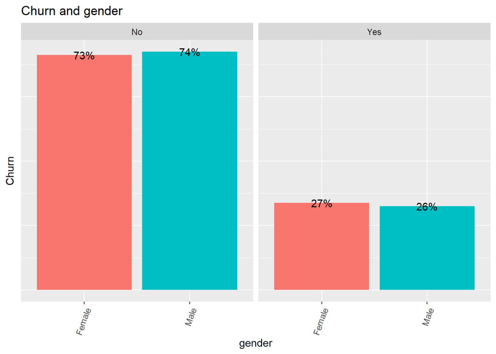

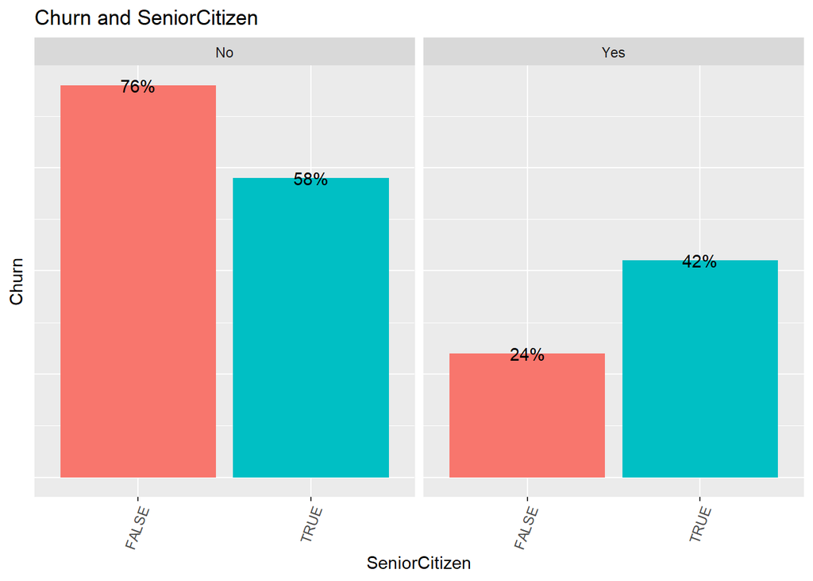

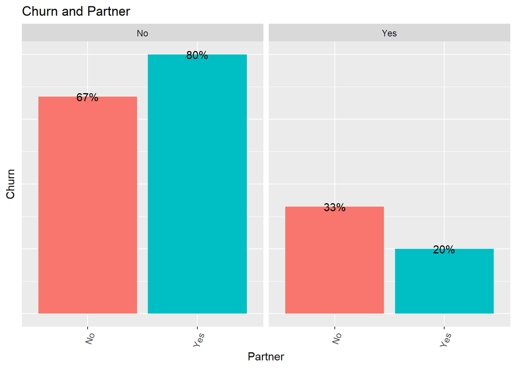

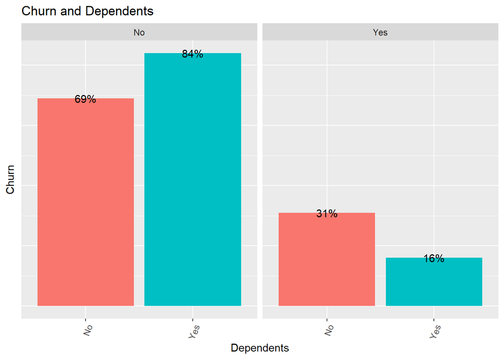

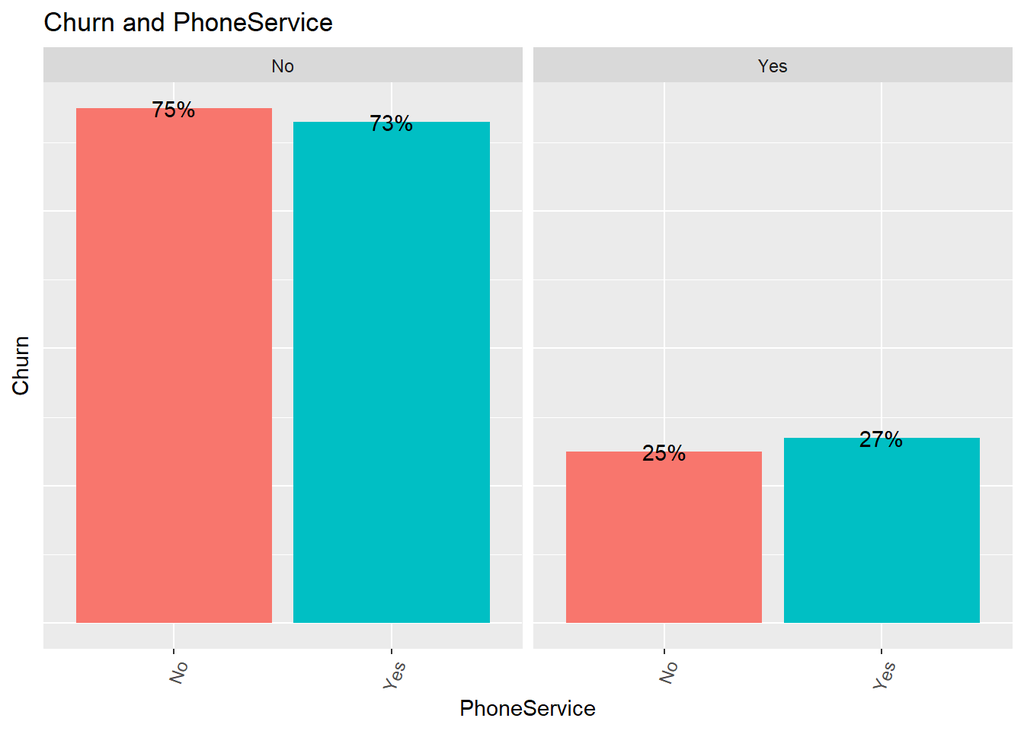

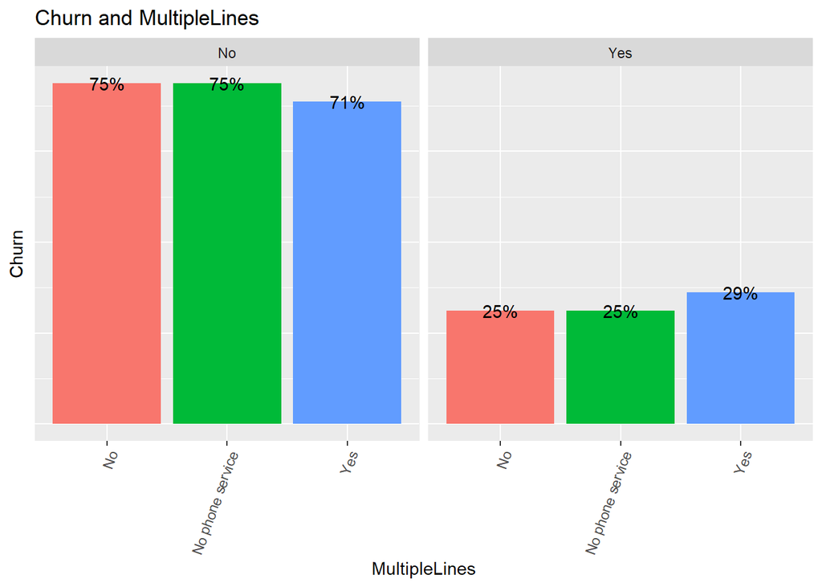

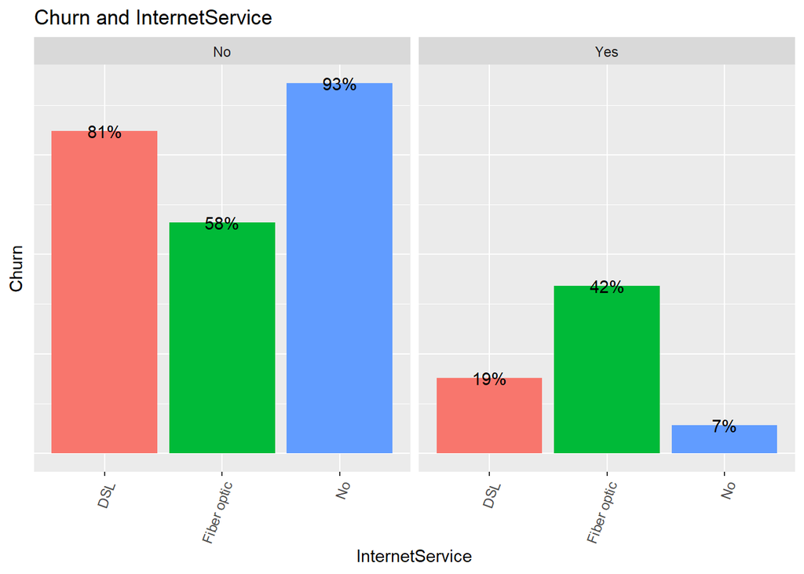

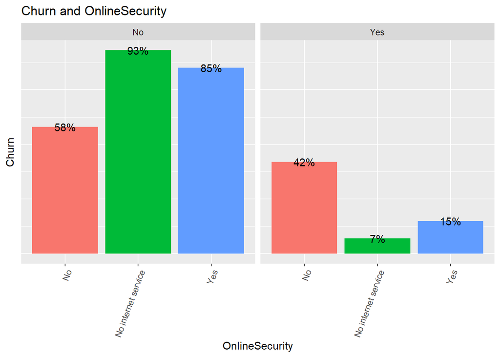

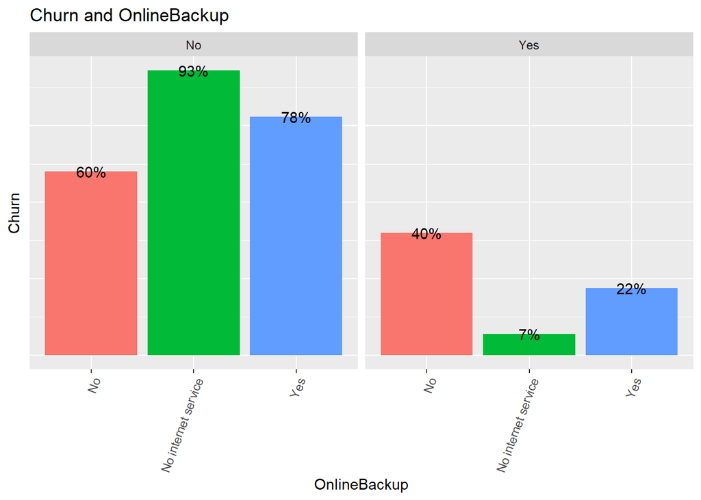

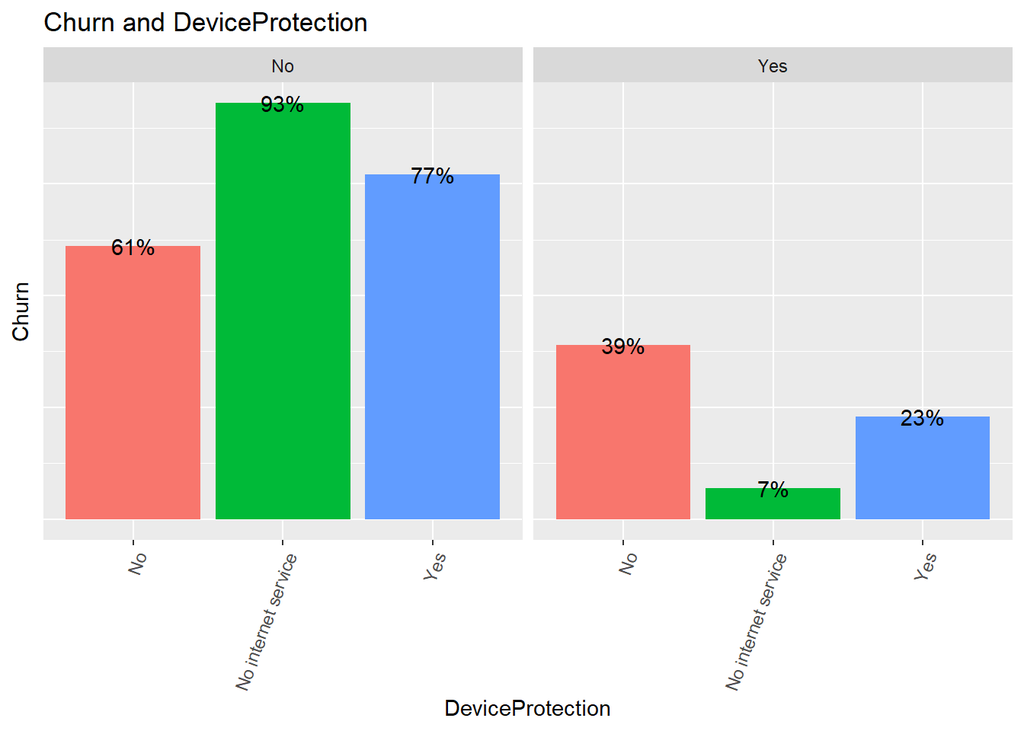

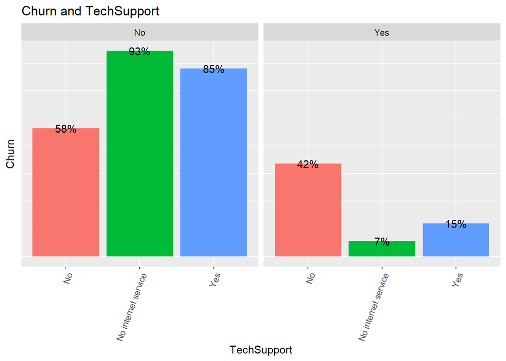

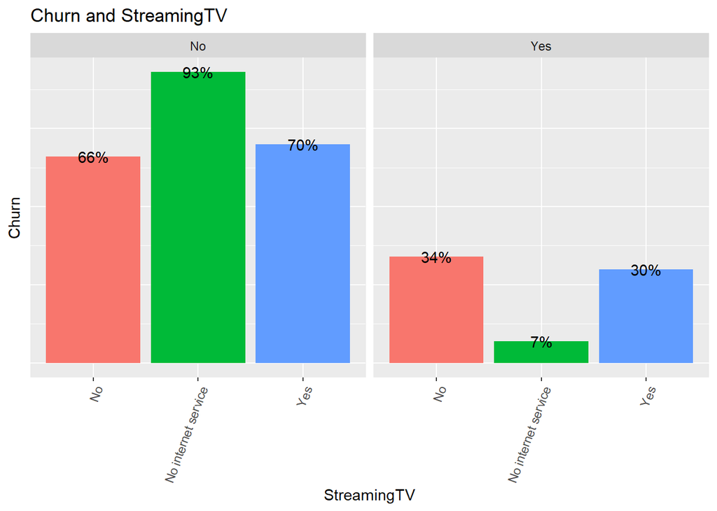

[4 more figures not shown]

```r
data.model <- subset(data, ,-c(customerID, gender,PhoneService, MultipleLines, TotalCharges))
```

> **Dự đoán với mô hình Decision Tree**

> **Decision tree** là một mô hình supervised learning. Cây quyết định ( Decision Tree ) là một cây phân cấp có cấu trúc được dùng để phân lớp các đối tượng dựa vào dãy các luật.

> Được sử dụng phổ biến là 2 tham số Information Gain và Gini index để đánh giá việc phân chia.

> **Information Gain** dựa trên sự giảm của hàm Entropy khi tập dữ liệu được phân chia trên một thuộc tính.

> **Gini index** tính độ lệch gini của node cha với tổng các giá trị gini có đánh trọng số của các node con.

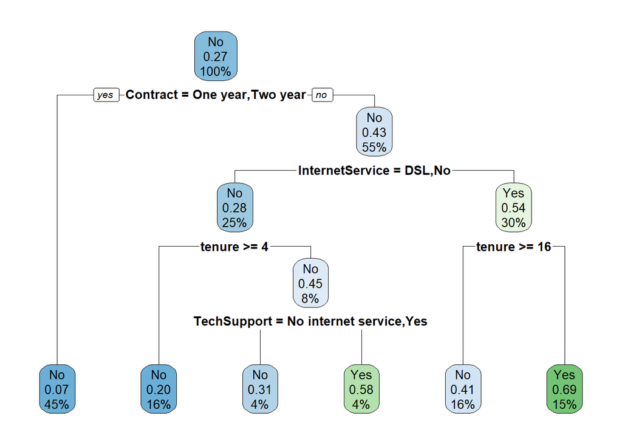

```
## Confusion Matrix and Statistics
##
##           Reference
## Prediction  No Yes
##        No  942 199
##        Yes  90 174
##
##                Accuracy : 0.7943
##                  95% CI : (0.7722, 0.8152)
##     No Information Rate : 0.7345
##     P-Value [Acc > NIR] : 1.131e-07
##
##                   Kappa : 0.4183
##
##  Mcnemar's Test P-Value : 2.112e-10
##
##             Sensitivity : 0.9128
##             Specificity : 0.4665
##          Pos Pred Value : 0.8256
##          Neg Pred Value : 0.6591
##              Prevalence : 0.7345
##          Detection Rate : 0.6705
##    Detection Prevalence : 0.8121
##       Balanced Accuracy : 0.6896
##
##        'Positive' Class : No
##
```

> AUC : The Area Under the Curve (AUC) Diện tích dưới đường cong (AUC) là **thước đo khả năng phân biệt giữa các lớp của một bộ phân loại** và được sử dụng như một bản tóm tắt của đường cong ROC. AUC càng cao, hiệu suất của mô hình càng tốt trong việc phân biệt giữa các lớp tích cực và tiêu cực.

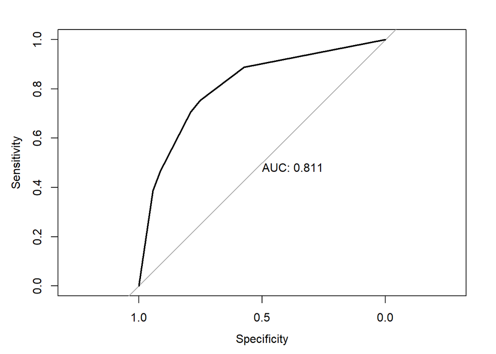

> **Cắt tỉa cây**
> - **Complexity parameter** (cp) : tham số độ phức tạp trong r để điều chỉnh độ sâu của cây.
> - CP sẽ quyết định có tiếp tục tách nút hay không .
> - Trước khi tách nút, lỗi là 0,5 và sau khi tách, lỗi là 0,1 thì quá trình tách sẽ hữu ích, trong đó như thể lỗi trước khi tách là 0,5 và sau khi tách là 0,48 thì không.
> - Giá trị mặc định là 0.01.
> - Để cắt tỉa cây, chúng tôi khám phá *bảng CP* được trả về trong rpart để tìm giá trị của tham số độ phức tạp với sai số dự đoán ước tính tối ưu. Sai số dự đoán ước tính của mỗi cây con (tương ứng với mỗi giá trị của CP) được chứa trong cột xerrorvà độ lệch chuẩn liên quan nằm trong cột xstd. Chúng tôi muốn tìm giá trị của CP mang lại một cây được cắt tỉa tương ứng với sai số dự đoán ước tính nhỏ nhất. Hàm printcp hiển thị bảng CP tương ứng với một rpartđối tượng
> - Ta sẽ chọn ra cây nhỏ nhất và có xerror nhỏ nhất.

```
##
## Classification tree:
## rpart(formula = Churn ~ ., data = train, method = "class")
##
## Variables actually used in tree construction:
## [1] Contract        InternetService TechSupport     tenure
##
## Root node error: 1496/5627 = 0.26586
##
## n= 5627
##
##         CP nsplit rel error  xerror     xstd
## 1 0.069742      0   1.00000 1.00000 0.022153
## 2 0.013703      3   0.79078 0.81751 0.020681
## 3 0.010000      5   0.76337 0.80816 0.020595
```

```
## [1] 0.01
```

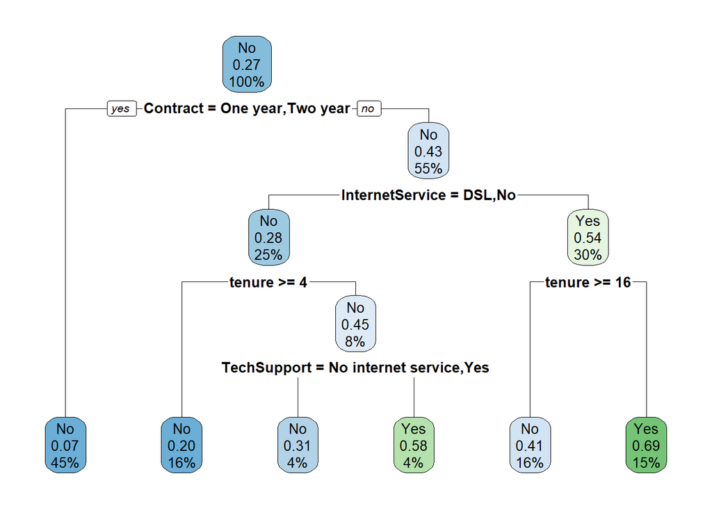

> **Nhận xét** : Sau khi thực hiện cắt tỉa cây : sau khi thực hiện ta nhận thấy cây nhận được giống với cây ban đầu. Tức là hàm rpart() ở trên (trước khi cắt tỉa đã chọn giá trị cp tốt nhất) và giá trị cp ở đây là 0.01.

## 2.2 Thuật toán Random FOrest

### 2.2.1 Tiền xử lí dữ liệu

> Change thay đổi giá trị No phone service ở cột MultipleLines thành no.

> Thay đổi giá trị ở cột SeniorCitizen, 0 sẽ thành no và 1 thành yes.

> Loại bỏ một số thuộc tính đầu vào có mối tương quan cao làm ảnh hưởng đến quá trình phân tích.

### 2.2.2 Model

> Training tập train bằng mô hình random forest.

```
##
## Call:
##  randomForest(formula = Churn ~ ., data = training)
##                Type of random forest: classification
##                      Number of trees: 500
## No. of variables tried at each split: 4
##
##         OOB estimate of  error rate: 22.43%
## Confusion matrix:
##       No Yes class.error
## No  3385 488   0.1260005
## Yes  695 707   0.4957204
```

> Độ chính xác của mô hình trên tập train.

```
## Confusion Matrix and Statistics
##
##           Reference
## Prediction   No  Yes
##        No  3636  233
##        Yes  237 1169
##
##                Accuracy : 0.9109
##                  95% CI : (0.9029, 0.9185)
##     No Information Rate : 0.7342
##     P-Value [Acc > NIR] : <2e-16
##
##                   Kappa : 0.7719
##
##  Mcnemar's Test P-Value : 0.8899
##
##             Sensitivity : 0.9388
##             Specificity : 0.8338
##          Pos Pred Value : 0.9398
##          Neg Pred Value : 0.8314
##              Prevalence : 0.7342
##          Detection Rate : 0.6893
##    Detection Prevalence : 0.7335
##       Balanced Accuracy : 0.8863
##
##        'Positive' Class : No
##
```

> Vẽ AUC

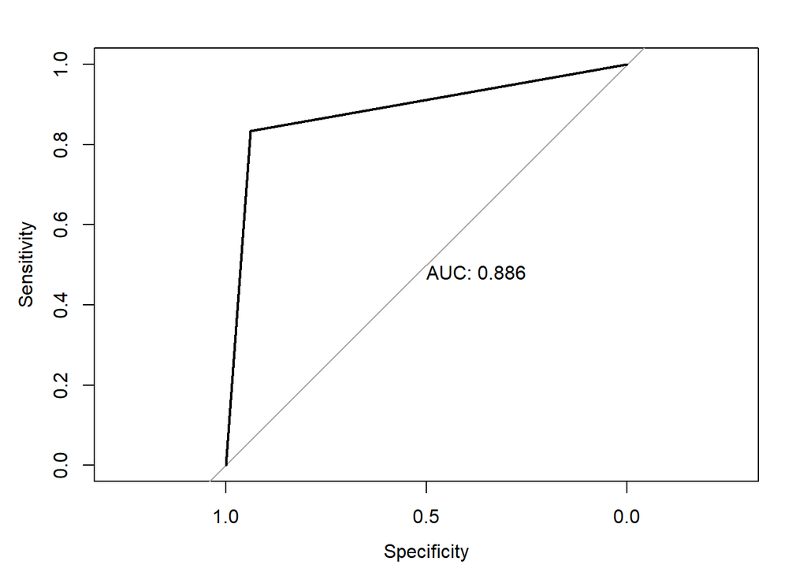

```
## mtry = 4  OOB error = 22.98%
## Searching left ...
## mtry = 8     OOB error = 23.64%
## -0.02887789 0.05
## Searching right ...
## mtry = 2     OOB error = 21.78%
## 0.0519802 0.05
## mtry = 1     OOB error = 24.28%
## -0.1148825 0.05
```

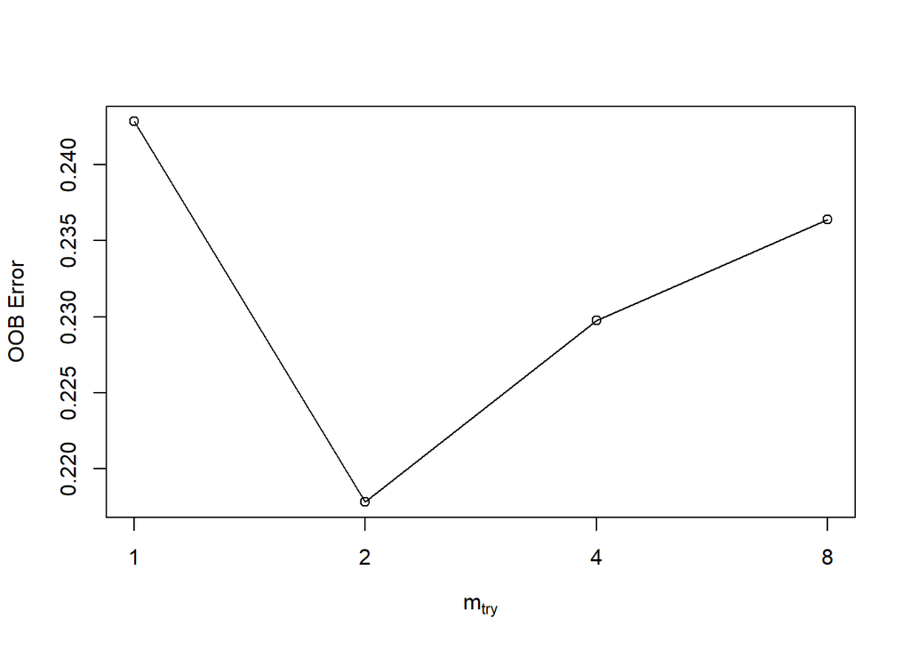

> Cải thiện mô hình với ntree=200, mtry=2 trên tập train.

```
##
## Call:
##  randomForest(formula = Churn ~ ., data = training, ntree = 200,      mtry = 2, importance = TRUE, proximity = TRUE)
##                Type of random forest: classification
##                      Number of trees: 200
## No. of variables tried at each split: 2
##
##         OOB estimate of  error rate: 22.14%
## Confusion matrix:
##       No Yes class.error
## No  3469 404   0.1043119
## Yes  764 638   0.5449358
```

> Áp dụng dự đoán lại trên tập test và xem lại độ chính xác trên tập train.

```
## Confusion Matrix and Statistics
##
##           Reference
## Prediction   No  Yes
##        No  1163  252
##        Yes  127  215
##
##                Accuracy : 0.7843
##                  95% CI : (0.7643, 0.8033)
##     No Information Rate : 0.7342
##     P-Value [Acc > NIR] : 6.973e-07
##
##                   Kappa : 0.3957
##
##  Mcnemar's Test P-Value : 1.897e-10
##
##             Sensitivity : 0.9016
##             Specificity : 0.4604
##          Pos Pred Value : 0.8219
##          Neg Pred Value : 0.6287
##              Prevalence : 0.7342
##          Detection Rate : 0.6619
##    Detection Prevalence : 0.8054
##       Balanced Accuracy : 0.6810
##
##        'Positive' Class : No
##
```

> Vẽ AUC trên tập test.

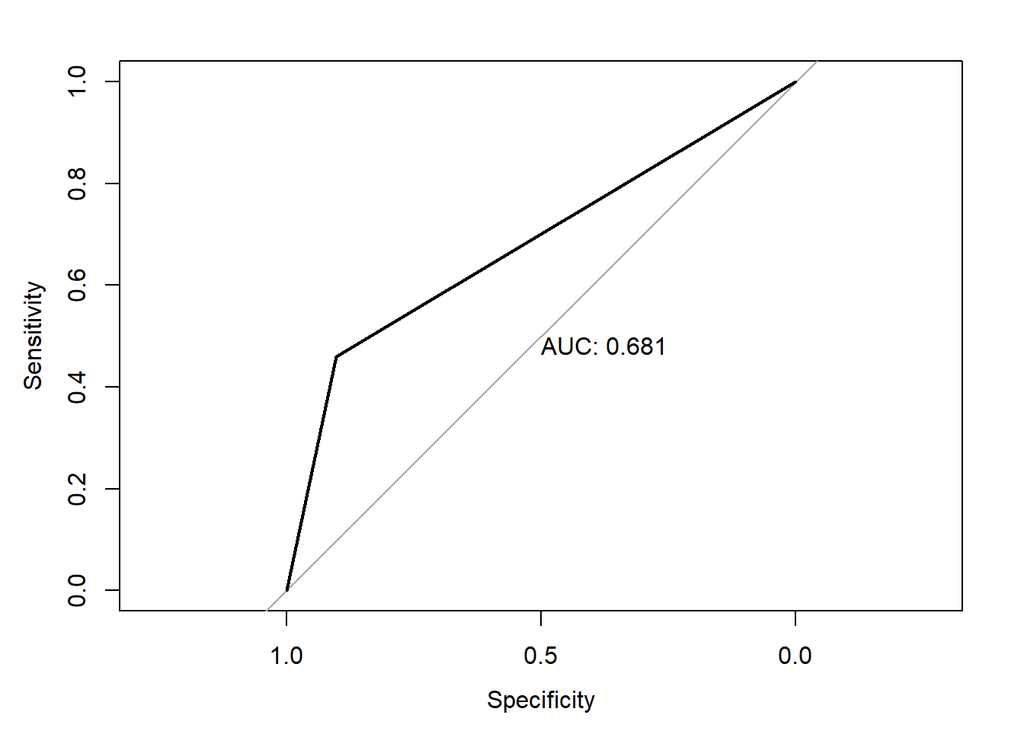

> Xác top 10 các biến có độ ảnh hưởng cao nhất đến mô hình

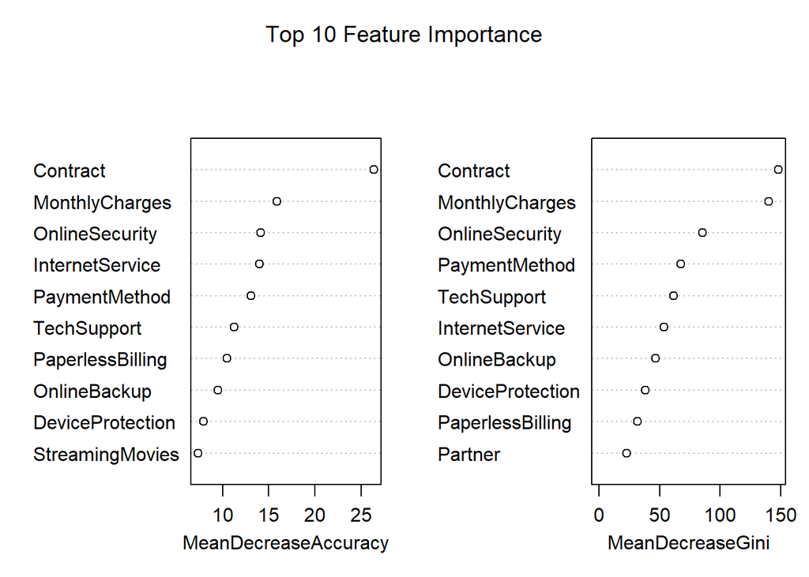

## 2.3 Thuật toán KNN

### 2.3.1 Tiền xư lí dữ liệu

> Loại bỏ biến không cần thiết là customerId **

> Loại bỏ các giá trị null

```
##           gender    SeniorCitizen          Partner       Dependents
##                0                0                0                0
##           tenure     PhoneService    MultipleLines  InternetService
##                0                0                0                0
##   OnlineSecurity     OnlineBackup DeviceProtection      TechSupport
##                0                0                0                0
##      StreamingTV  StreamingMovies         Contract PaperlessBilling
##                0                0                0                0
##    PaymentMethod   MonthlyCharges     TotalCharges            Churn
##                0                0                0                0
```

```
## 'data.frame':    7032 obs. of  20 variables:
##  $ gender          : chr  "Female" "Male" "Male" "Male" ...
##  $ SeniorCitizen   : int  0 0 0 0 0 0 0 0 0 0 ...
##  $ Partner         : chr  "Yes" "No" "No" "No" ...
##  $ Dependents      : chr  "No" "No" "No" "No" ...
##  $ tenure          : int  1 34 2 45 2 8 22 10 28 62 ...
##  $ PhoneService    : chr  "No" "Yes" "Yes" "No" ...
##  $ MultipleLines   : chr  "No phone service" "No" "No" "No phone service" ...
##  $ InternetService : chr  "DSL" "DSL" "DSL" "DSL" ...
##  $ OnlineSecurity  : chr  "No" "Yes" "Yes" "Yes" ...
##  $ OnlineBackup    : chr  "Yes" "No" "Yes" "No" ...
##  $ DeviceProtection: chr  "No" "Yes" "No" "Yes" ...
##  $ TechSupport     : chr  "No" "No" "No" "Yes" ...
##  $ StreamingTV     : chr  "No" "No" "No" "No" ...
##  $ StreamingMovies : chr  "No" "No" "No" "No" ...
##  $ Contract        : chr  "Month-to-month" "One year" "Month-to-month" "One year" ...
##  $ PaperlessBilling: chr  "Yes" "No" "Yes" "No" ...
##  $ PaymentMethod   : chr  "Electronic check" "Mailed check" "Mailed check" "Bank transfer (automatic)" ...
##  $ MonthlyCharges  : num  29.9 57 53.9 42.3 70.7 ...
##  $ TotalCharges    : num  29.9 1889.5 108.2 1840.8 151.7 ...
##  $ Churn           : chr  "No" "No" "Yes" "No" ...
##  - attr(*, "na.action")= 'omit' Named int [1:11] 489 754 937 1083 1341 3332 3827 4381 5219 6671 ...
##   ..- attr(*, "names")= chr [1:11] "489" "754" "937" "1083" ...
```

> Tạo hàm giúp tính độ chính xác của mô hình

```r
cost_matrix <- matrix(c(1,0,0,1), nrow = 2)
cost_matrix
```

```
##      [,1] [,2]
## [1,]    1    0
## [2,]    0    1
```

```r
accuracy <- function(cm){
  return(cm*cost_matrix)
}
```

> Chia tập train thành 7 fold để train bằng phương pháp cross validation

### 2.3.2 Model

> Tạo ma trận lưu kết quả của mỗi k

```
## [1] 5625
```

```
## [1] 5625
```

> Huấn luyện mô hình và lưu kết quả vào ma trận kết quả đã tạo với tham số k từ 1 tới 100

> Đồ thị kết quả theo k

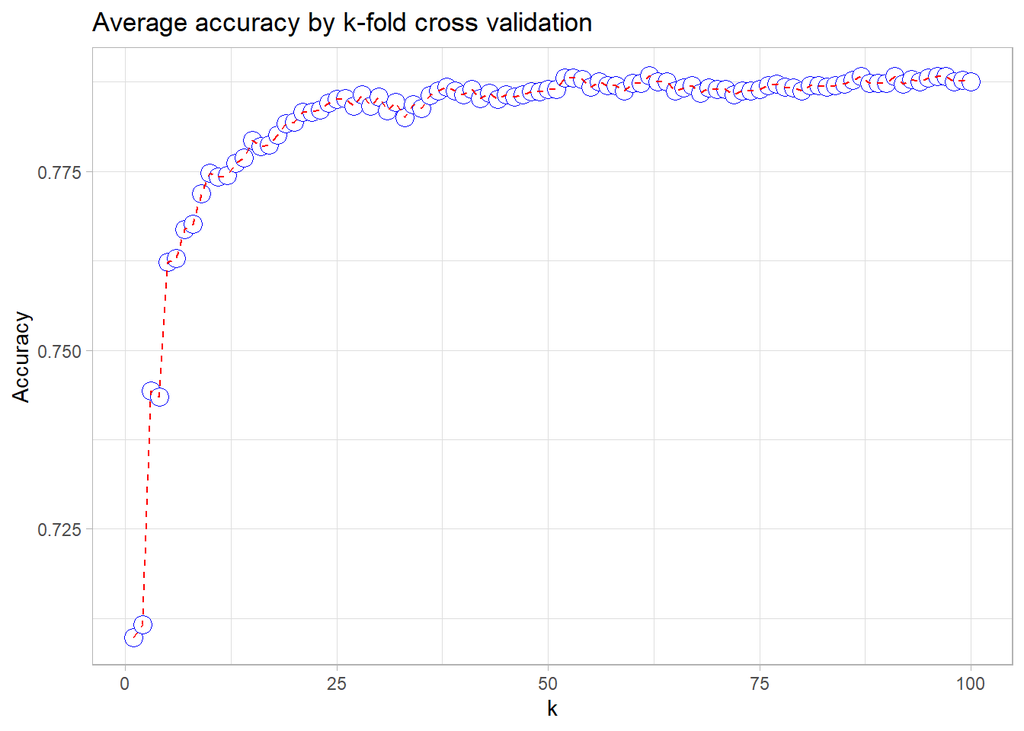

> Tìm giá trị k tốt nhất

```
## [1] 62
```

> Dự đoán mô hình với tập test

> Độ chính xác

```
## [1] 0.7867804
```

> AUC

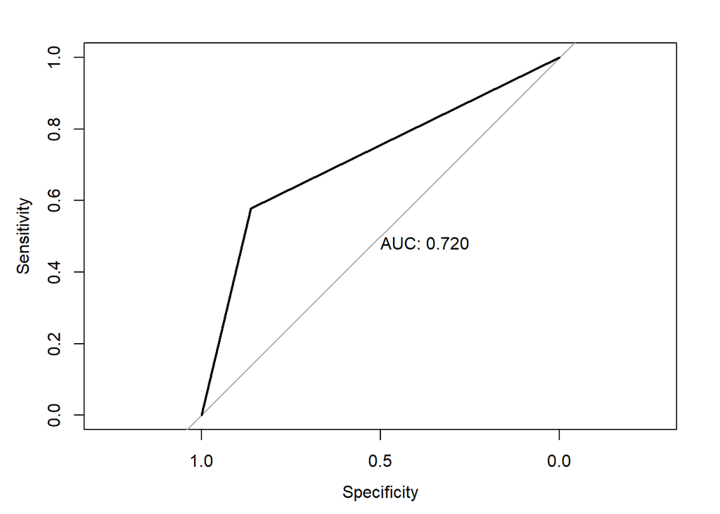

> **Nhận xét :**

> Mô hình chưa đem lại hiệu quả cao

## 2.4 Thuật toán Logistic Regression

### 2.3.1 Tiền xư lí dữ liệu

```
##
##  0-1 year 1-2 years 2-3 years 3-4 years 4-5 years 5-6 years
##      2186      1024       832       762       832      1407
```

> Chuyển các giá trị phân loại thành (0, 1)

> Xóa customerID và thực hiện mã hóa một lần để tạo các biến giả cho tất cả các biến đặc tính.

> Xóa các hàng có “No phone service”

> Loại bỏ mức cuối cùng của mỗi yếu tố để tránh các điểm kỳ dị

### 2.4.2 Model

> Cross Validation (Confusion Matrix & ROC)

> Trên Train set

```
## Confusion Matrix and Statistics
##
##           Reference
## Prediction   No  Yes
##        No  3501  726
##        Yes  342  665
##
##                Accuracy : 0.7959
##                  95% CI : (0.7848, 0.8068)
##     No Information Rate : 0.7342
##     P-Value [Acc > NIR] : < 2.2e-16
##
##                   Kappa : 0.4267
##
##  Mcnemar's Test P-Value : < 2.2e-16
##
##             Sensitivity : 0.9110
##             Specificity : 0.4781
##          Pos Pred Value : 0.8282
##          Neg Pred Value : 0.6604
##              Prevalence : 0.7342
##          Detection Rate : 0.6689
##    Detection Prevalence : 0.8076
##       Balanced Accuracy : 0.6945
##
##        'Positive' Class : No
##
```

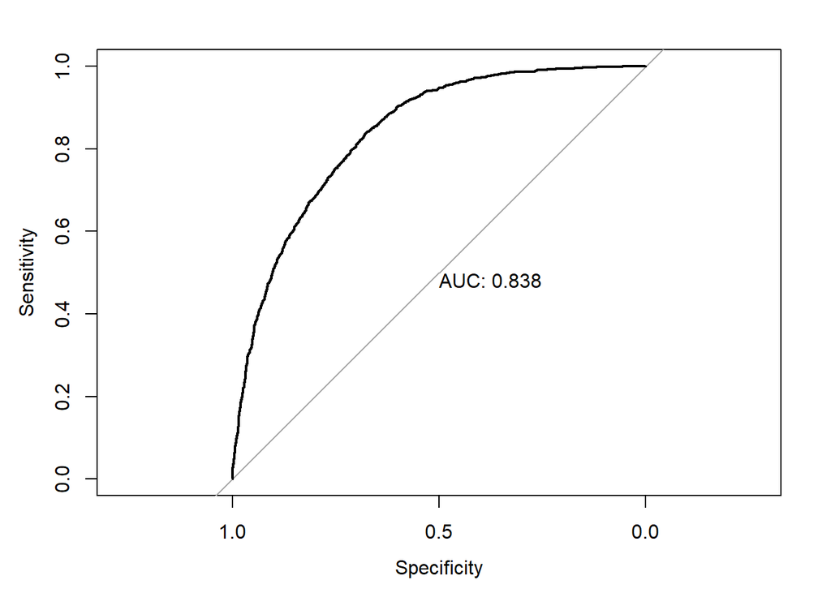

> Trên Test set

```
## Confusion Matrix and Statistics
##
##           Reference
## Prediction   No  Yes
##        No  1216  250
##        Yes  115  228
##
##                Accuracy : 0.7982
##                  95% CI : (0.779, 0.8165)
##     No Information Rate : 0.7358
##     P-Value [Acc > NIR] : 3.474e-10
##
##                   Kappa : 0.4295
##
##  Mcnemar's Test P-Value : 2.318e-12
##
##             Sensitivity : 0.9136
##             Specificity : 0.4770
##          Pos Pred Value : 0.8295
##          Neg Pred Value : 0.6647
##              Prevalence : 0.7358
##          Detection Rate : 0.6722
##    Detection Prevalence : 0.8104
##       Balanced Accuracy : 0.6953
##
##        'Positive' Class : No
##
```

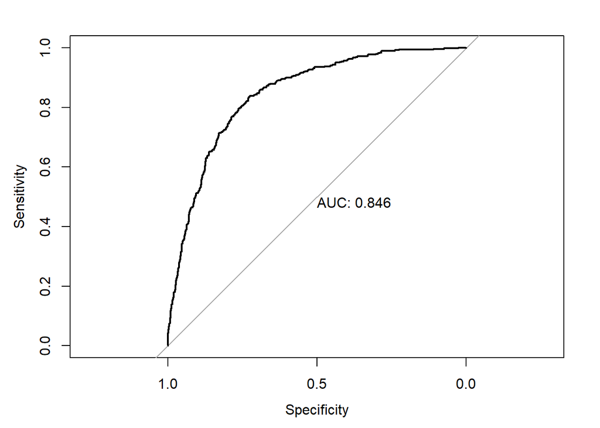

> Model này rất tốt vì acc và AUC không có sự khác biệt lớn trên 2 tạp train test

> Nhưng chỉ số Specificities ở 2 tập còn rất thấp khoảng 0.46

# 3. TỔng kết

## 3.2 Những chính sách cho Cty sau khi thu được kết quả từ model

> Ràng buộc khách hàng mới bằng hợp đồng từ 1 đến 2 năm.

> Đẩy mạnh việc thanh toán của khách hàng qua automatic bằng hoàn tiền hoặc khuyến mãi.

> Cơ sở hạ tầng & trình độ công nghệ của OnlineSecurity, OnlineBackup, StreamingMovies, StreamingTV cần được cải thiện hàng loạt. Cần phân tích nguyên nhân gốc rễ về mặt kỹ thuật vì những yếu tố này đang ảnh hưởng đến tỷ lệ khách hàng sử dụng Internet cao nhất.

> Khách hàng sử dụng dịch vụ cáp quang (InternetService : fiber optic )có tỷ lệ rời đi (churn : yes ) cao hơn khách hàng DSL (cáp đồng). Công nghệ và cơ sở hạ tầng của dịch vụ cáp quang cần được cải thiện. Đồng thời, xem xét các ưu đãi và giảm giá để thu hút khách hàng mới đăng ký để cải thiện dịch vụ này.